# Correr un notebook dentro de otro en Deepnote

¡Hola! Te doy la bienvenida a este pequeño tutorial para conocer cómo ejecutar las funciones de una Jupyter Notebook dentro de otra en Deepnote.

Por una actualización de Deepnote notarás que ahora las Notebooks están separadas de los archivos (Files).

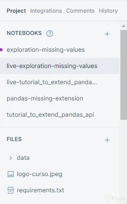

Por esta actualización tendrás que subir la notebook al sistema de archivos de Deepnote, para poder ejecutarla dentro de otra notebook utilizando la magia %run.

[figure not shown]

Tendrás que hacer lo anterior en tu proyecto de Deepnote del curso, ya que utilizaremos una notebook llamada `pandas-missing-extension.ipynb` dentro de nuestra notebook principal para utilizar métodos predefinidos en ella. Por ahora, no te preocupes por el contenido de esa notebook, en la siguiente clase hablaremos de ello. 🤗

Sigue estos pasos para subir tu notebook como archivo (File) a Deepnote:

1. Ve a la sección de NOTEBOOKS del proyecto de Deepnote.

[figure not shown]

2. Da clic en los tres puntos sobre la notebook `pandas-missing-extension` y da clic sobre `Export as .ipynb`. Esto descargará la notebook a tu computadora.

[figure not shown]

3. Después da clic en en el signo de + en la sección FILES y sube la notebook `pandas-missing-extension.ipynb` que descargaste en el paso anterior en la opción `Upload File`.

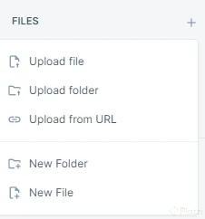

[figure not shown]

¡Nos vemos en la próxima clase! Conoceremos cómo funciona la notebook donde extendemos Pandas para manejar valores faltantes! 🤓✨

## Extra:

[figure not shown]

Aporte de Diego Cesar Lerma Torres

Estoy trabajando en Visual Studio Code

Si también trabajas en VSCode, sigue este tutorial para importar `pandas-missing-extension` como un modulo para nuestro notebook principal:

### Tutorial para Importar un Jupyter Notebook como Módulo en otro Notebook

#### Pasos Preliminares

- **Preparación del Entorno de Trabajo:** Asegúrate de que tienes instalado Visual Studio Code y la extensión de Jupyter para este editor.
- **Organización de Archivos:** Coloca el archivo notebook `pandas-missing-extension.ipynb` en la misma carpeta donde se encuentra el notebook en el que deseas importar el contenido.

#### Exportación del Notebook a un Script de Python

- **Exportar el Notebook:** Abre el archivo `pandas-missing-extension.ipynb` con Visual Studio Code.  
  Ve a la barra donde agregas bloques de código y el Kernel, `selecciona ... > Exportar > Script de Python`. Esto convertirá tu notebook en un script.py.
- **Guardado del Archivo Exportado:** Elige la carpeta donde deseas guardar el script. Si vas a importar el contenido en un notebook que se encuentra en la misma carpeta, guárdalo allí.  
  Dale al archivo exportado un nombre que cumpla con las convenciones de nombres de Python (sin guiones). Por ejemplo: `pandas_missing_extension.py`

#### Importación del Módulo en el Notebook Destino

- **Importar el Módulo:** Vuelve al notebook en el que deseas utilizar las funciones o clases definidas en `pandas-missing-extension.ipynb`  
  En una celda nueva, escribe el comando de importación utilizando el nombre correcto del archivo script de Python, por ejemplo: `import pandas_missing_extension`

#### Consejos Finales

- Mantén una estructura de carpetas limpia y bien organizada para facilitar la importación y el mantenimiento del código.
- Asegúrate de documentar el proceso dentro de tus notebooks para que otros puedan seguir tus pasos.

> Este tutorial te ayudará a importar eficientemente el contenido de un notebook de Jupyter en otro, utilizando Visual Studio Code, de una manera que es fácil de seguir y de replicar en el futuro.